# A Frequência Escolar Obrigatória Afeta a Escolaridade e os Rendimentos?

Autor

Vitor Vasconcelos

## 1 Estudo baseado no artigo “*Does Compulsory School Attendance Affect Schooling and Earnings?” -* **Joshua D. Angrist and Alan B. Krueger (1991)**

Link do artigo original que estamos usando como base: [Does Compulsory School Attendance Affect Schooling and Earnings?](https://www.nber.org/system/files/working_papers/w3572/w3572.pdf)

Para a construção do código usei como referência direta o material: [R Code for Mastering ’Metrics](https://jrnold.github.io/masteringmetrics/quarter-of-birth-and-returns-to-schooling.html).

O objetivo central desta análise é estimar o efeito causal da educação (anos adicionais de estudo, $X$) no salário futuro ($Y$), utilizando o trimestre de nascimento ($Z$) como instrumento para isolar o viés de habilidade ($U$), que atua como uma variável de confusão.

Em regressões tradicionais, o retorno financeiro da educação costuma ser inflacionado por esse **viés de habilidade**: pessoas naturalmente mais aptas ou motivadas tendem a estudar mais e, simultaneamente, a ganhar mais no mercado de trabalho.

Para isolar o efeito puro da escola, Angrist e Krueger exploram um experimento natural: a interação entre o **trimestre de nascimento** e as **leis de escolaridade obrigatória**. No artigo, os autores demonstram que o trimestre do ano em que um aluno nasce afeta diretamente o seu nível de escolaridade final. Isso ocorre porque as políticas de idade mínima para ingresso escolar fazem com que os alunos nascidos no início do ano atinjam a idade legal para evasão (geralmente 16 anos) tendo acumulado menos tempo de sala de aula do que os seus colegas nascidos no final do ano.

As estimativas indicam que cerca de 25% dos potenciais desistentes acabam permanecendo na escola apenas devido a essa obrigatoriedade legal.

Como é altamente improvável que o trimestre de nascimento de alguém esteja correlacionado com atributos pessoais inatos, como inteligência ou motivação ($U$), o trimestre torna-se uma **variável exógena** perfeita. Ou seja, é uma variável determinada fora do modelo (um fator biológico aleatório) que afeta a educação ($X$), mas que não possui nenhuma relação direta com o salário ($Y$) a não ser através do tempo extra passado na escola.

### 1.1 Preparação do Ambiente e Importação dos Dados

Inicialmente carreguei as mesmas bibliotecas usadas pela referência para a análise de dados e estimação de modelos com Variáveis Instrumentais (VI).

```r
library("AER")
library("sandwich")
library("lmtest")
library("tidyverse")
library("broom")
```

Os dados originais derivam do Censo dos EUA (1980). Utilizaremos uma base previamente tratada para focar na mecânica da inferência causal. Criamos uma variável dummy/indicadora (q4) que identifica os indivíduos nascidos no 4º trimestre. Como a lei obriga a entrada na escola no início do ano letivo, quem nasce no final do ano entra mais novo e, consequentemente, é forçado pela lei de escolaridade obrigatória a passar mais tempo na escola antes de atingir a idade legal de evasão.

```r
url_dados <- "https://raw.githubusercontent.com/matheusfacure/python-causality-handbook/master/causal-inference-for-the-brave-and-true/data/ak91.csv"

ak91 <- read_csv(url_dados) %>%
  mutate(q4 = as.numeric(quarter_of_birth == 4))

knitr::kable(head(ak91))
```

| log_wage | years_of_schooling | year_of_birth | quarter_of_birth | state_of_birth | q4 |
| --- | --- | --- | --- | --- | --- |
| 5.790019 | 12 | 30 | 1 | 45 | 0 |
| 5.952494 | 11 | 30 | 1 | 45 | 0 |
| 5.315949 | 12 | 30 | 1 | 45 | 0 |
| 5.595926 | 12 | 30 | 1 | 45 | 0 |
| 6.068915 | 12 | 30 | 1 | 37 | 0 |
| 5.793871 | 11 | 30 | 1 | 45 | 0 |

### 1.2 Dicionário de Variáveis

| Variável | Tipo | Descrição |
| --- | --- | --- |
| `log_wage` | Contínua | Logaritmo natural do salário semanal. |
| `years_of_schooling` | Discreta | Anos totais de educação formal concluídos. |
| `quarter_of_birth` | Categórica | Trimestre de nascimento do indivíduo (1 a 4). |
| `year_of_birth` | Categórica | Ano de nascimento do indivíduo (1930 a 1939). |
| `q4` | Indicadora (Dummy) | Assume valor 1 se o indivíduo nasceu no 4º trimestre, e 0 caso contrário. |

### 1.3 O Estimador de Wald (A Lógica Básica)

O Estimador de Wald calcula o efeito causal dividindo o impacto do instrumento na variável de resultado pelo impacto do instrumento na variável endógena (Primeiro Estágio).

$$\hat{\beta}_{Wald} = \frac{\Delta \text{Salário}}{\Delta \text{Escolaridade}} = \frac{E[\text{Salário} \mid \text{4º Trimestre}] - E[\text{Salário} \mid \text{Outros Trimestres}]}{E[\text{Escolaridade} \mid \text{4º Trimestre}] - E[\text{Escolaridade} \mid \text{Outros Trimestres}]}$$

Numerador: Qual o impacto de nascer no 4º trimestre no salário?

```r
mod1 <- lm(log_wage ~ q4, data = ak91)
coeftest(mod1, vcov = sandwich)
```

```
t test of coefficients:

             Estimate Std. Error   t value Pr(>|t|)
(Intercept) 5.8982723  0.0013625 4329.1303  < 2e-16 ***
q4          0.0068132  0.0027433    2.4836  0.01301 *
---
Signif. codes:  0 '***' 0.001 '**' 0.01 '*' 0.05 '.' 0.1 ' ' 1
```

Denominador: Qual o impacto de nascer no 4º trimestre nos anos de escolaridade?

```r
mod2 <- lm(years_of_schooling ~ q4, data = ak91)
coeftest(mod2, vcov = sandwich)
```

```
t test of coefficients:

              Estimate Std. Error   t value  Pr(>|t|)
(Intercept) 12.7473106  0.0066085 1928.9230 < 2.2e-16 ***
q4           0.0921209  0.0131613    6.9994 2.576e-12 ***
---
Signif. codes:  0 '***' 0.001 '**' 0.01 '*' 0.05 '.' 0.1 ' ' 1
```

**Mínimos Quadrados em Dois Estágios - TSLS:**

A função ivreg realiza a operação do Estimador de Wald de forma integrada, utilizando q4 como instrumento para limpar a variável years_of_schooling da sua endogeneidade.

```r
mod3 <- ivreg(log_wage ~ years_of_schooling | q4, data = ak91)
coeftest(mod3, vcov = sandwich)
```

```
t test of coefficients:

                   Estimate Std. Error t value  Pr(>|t|)
(Intercept)        4.955495   0.357736 13.8524 < 2.2e-16 ***
years_of_schooling 0.073959   0.028014  2.6401  0.008289 **
---
Signif. codes:  0 '***' 0.001 '**' 0.01 '*' 0.05 '.' 0.1 ' ' 1
```

### 1.4 O regressão ingénua via Mínimos Quadrados Ordinários (OLS)

Para efeitos de comparação, vejamos a regressão ingénua via Mínimos Quadrados Ordinários (OLS), que desconsidera o viés de habilidade:

```r
mod4 <- lm(log_wage ~ years_of_schooling, data = ak91)
coeftest(mod4, vcov = sandwich)
```

```
t test of coefficients:

                     Estimate Std. Error t value  Pr(>|t|)
(Intercept)        4.99518232 0.00507386  984.49 < 2.2e-16 ***
years_of_schooling 0.07085104 0.00038102  185.95 < 2.2e-16 ***
---
Signif. codes:  0 '***' 0.001 '**' 0.01 '*' 0.05 '.' 0.1 ' ' 1
```

*Nota: A diferença relativamente pequena entre a estimativa OLS e a estimativa de VI foi um dos grandes achados de Angrist e Krueger, sugerindo que o viés de habilidade pode não ser tão massivo quanto se teorizava para esta população.*

Se precisarmos de testes de diagnóstico adicionais (como o teste de instrumentos fracos), aplicamos o argumento `diagnostics = TRUE`:

```r
mod5 <- ivreg(log_wage ~ years_of_schooling | q4, data = ak91)
summary(mod5, vcov = sandwich, diagnostics = TRUE)
```

```
Call:
ivreg(formula = log_wage ~ years_of_schooling | q4, data = ak91)

Residuals:
    Min      1Q  Median      3Q     Max
-8.7765 -0.2393  0.0713  0.3326  4.6536

Coefficients:
                   Estimate Std. Error t value Pr(>|t|)
(Intercept)         4.95549    0.35774   13.85  < 2e-16 ***
years_of_schooling  0.07396    0.02801    2.64  0.00829 **

Diagnostic tests:
                    df1    df2 statistic  p-value
Weak instruments      1 329507    48.991 2.58e-12 ***
Wu-Hausman            1 329506     0.012    0.912
Sargan                0     NA        NA       NA
---
Signif. codes:  0 '***' 0.001 '**' 0.01 '*' 0.05 '.' 0.1 ' ' 1

Residual standard error: 0.6379 on 329507 degrees of freedom
Multiple R-Squared: 0.1171, Adjusted R-squared: 0.1171
Wald test:  6.97 on 1 and 329507 DF,  p-value: 0.008289
```

#### 1.4.1 Testes dos Instrumentos Fracos (Weak Instruments)

Na matemática das Variáveis Instrumentais, o Estimador de Wald é essencialmente uma divisão. O nosso **Primeiro Estágio** (o impacto do trimestre na escolaridade) é o denominador dessa conta.

Se o instrumento for **fraco** — ou seja, se o trimestre de nascimento tiver um impacto quase nulo no tempo de escola —, o nosso denominador aproxima-se de zero. Matematicamente, dividir por zero (ou por ruído) faz com que a variância do nosso estimador expluda e os resultados percam qualquer validade estatística. Pior ainda: em amostras reais, um instrumento fraco faz com que a estimativa perca o seu “poder de limpeza” e seja sugada de volta para o resultado enviesado do OLS.

Para garantir que estamos seguros, usamos o argumento `diagnostics = TRUE` na função `ivreg`, que executa um **Teste F** no Primeiro Estágio.

- **A Regra de Ouro (Stock-Yogo):** A literatura econométrica estabelece que a **Estatística F deve ser maior que 10** ($F > 10$).
- Se observar o output do nosso modelo na linha `Weak instruments`, verá que a nossa Estatística F é de aproximadamente **48.99**, com um p-valor ínfimo.

Isto prova que a lei de escolaridade obrigatória aliada ao trimestre de nascimento não é apenas uma teoria curiosa; é um **instrumento extremamente forte e robusto** para mover a escolaridade!

### 1.5 Modelos com Controlos: A Idade Importa

No mundo real, o salário cresce com a idade. Como os nascidos no início do ano são ligeiramente mais velhos do que os nascidos no fim do mesmo ano, precisamos de controlar o ano de nascimento para não confundir o efeito da idade com o efeito da escolaridade.

Recriamos as variáveis para garantir que o ano e o trimestre de nascimento sejam tratados como fatores (variáveis categóricas).

```r
ak91 <- read_csv(url_dados) %>%
  mutate(
    q4 = as.numeric(quarter_of_birth == 4),
    yob_fct = factor(year_of_birth),
    qob_fct = factor(quarter_of_birth)
  )
```

Comparação dos modelos controlando pelo ano de nascimento (YOB):

**OLS com Controlo:**

```r
mod6 <- lm(log_wage ~ years_of_schooling + yob_fct, data = ak91)
coeftest(mod6, vcov = sandwich)
```

```
t test of coefficients:

                      Estimate  Std. Error  t value  Pr(>|t|)
(Intercept)         5.01734829  0.00601856 833.6462 < 2.2e-16 ***
years_of_schooling  0.07108105  0.00038146 186.3413 < 2.2e-16 ***
yob_fct31          -0.00638745  0.00512350  -1.2467 0.2125091
yob_fct32          -0.01483837  0.00505201  -2.9371 0.0033130 **
yob_fct33          -0.01758316  0.00506837  -3.4692 0.0005221 ***
yob_fct34          -0.02099926  0.00506207  -4.1484 3.350e-05 ***
yob_fct35          -0.03289468  0.00503939  -6.5275 6.697e-11 ***
yob_fct36          -0.03178077  0.00497019  -6.3943 1.615e-10 ***
yob_fct37          -0.03671211  0.00489441  -7.5008 6.357e-14 ***
yob_fct38          -0.03689046  0.00485633  -7.5964 3.054e-14 ***
yob_fct39          -0.04816363  0.00483329  -9.9650 < 2.2e-16 ***
---
Signif. codes:  0 '***' 0.001 '**' 0.01 '*' 0.05 '.' 0.1 ' ' 1
```

**Variáveis Instrumentais (Instrumento Único + Controlo):** Repare que as covariáveis exógenas (`yob_fct`) devem entrar tanto na equação principal quanto na lista de instrumentos.

```r
mod7 <- ivreg(log_wage ~ years_of_schooling + yob_fct | q4 + yob_fct, data = ak91)
summary(mod7, vcov = sandwich, diagnostics = TRUE)
```

```
Call:
ivreg(formula = log_wage ~ years_of_schooling + yob_fct | q4 +
    yob_fct, data = ak91)

Residuals:
     Min       1Q   Median       3Q      Max
-8.77851 -0.23456  0.07187  0.34052  4.66866

Coefficients:
                    Estimate Std. Error t value Pr(>|t|)
(Intercept)         4.965992   0.353929  14.031  < 2e-16 ***
years_of_schooling  0.075204   0.028414   2.647  0.00813 **
yob_fct31          -0.006958   0.006466  -1.076  0.28195
yob_fct32          -0.015568   0.007082  -2.198  0.02792 *
yob_fct33          -0.018546   0.008327  -2.227  0.02593 *
yob_fct34          -0.022094   0.009094  -2.430  0.01512 *
yob_fct35          -0.034251   0.010608  -3.229  0.00124 **
yob_fct36          -0.033377   0.012079  -2.763  0.00572 **
yob_fct37          -0.038565   0.013681  -2.819  0.00482 **
yob_fct38          -0.039098   0.015963  -2.449  0.01432 *
yob_fct39          -0.050533   0.017050  -2.964  0.00304 **

Diagnostic tests:
                    df1    df2 statistic  p-value
Weak instruments      1 329498    47.732 4.89e-12 ***
Wu-Hausman            1 329497     0.021    0.885
Sargan                0     NA        NA       NA
---
Signif. codes:  0 '***' 0.001 '**' 0.01 '*' 0.05 '.' 0.1 ' ' 1

Residual standard error: 0.6378 on 329498 degrees of freedom
Multiple R-Squared: 0.1173, Adjusted R-squared: 0.1173
Wald test: 1.806 on 10 and 329498 DF,  p-value: 0.05402
```

**O Modelo Robusto (Múltiplos Instrumentos):** Em vez de usar apenas uma *dummy* para o 4º trimestre, utilizamos todos os trimestres do ano como instrumentos para gerar ainda mais variação exógena.

```r
mod8 <- ivreg(log_wage ~ years_of_schooling + yob_fct | qob_fct + yob_fct, data = ak91)
summary(mod8, vcov = sandwich, diagnostics = TRUE)
```

```
Call:
ivreg(formula = log_wage ~ years_of_schooling + yob_fct | qob_fct +
    yob_fct, data = ak91)

Residuals:
    Min      1Q  Median      3Q     Max
-8.9945 -0.2544  0.0676  0.3509  4.8425

Coefficients:
                    Estimate Std. Error t value Pr(>|t|)
(Intercept)         4.591739   0.250574  18.325  < 2e-16 ***
years_of_schooling  0.105252   0.020115   5.232 1.67e-07 ***
yob_fct31          -0.011113   0.005906  -1.882 0.059878 .
yob_fct32          -0.020886   0.006227  -3.354 0.000796 ***
yob_fct33          -0.025565   0.006976  -3.665 0.000248 ***
yob_fct34          -0.030072   0.007421  -4.053 5.07e-05 ***
yob_fct35          -0.044136   0.008363  -5.278 1.31e-07 ***
yob_fct36          -0.045008   0.009301  -4.839 1.30e-06 ***
yob_fct37          -0.052070   0.010335  -5.038 4.70e-07 ***
yob_fct38          -0.055185   0.011840  -4.661 3.15e-06 ***
yob_fct39          -0.067800   0.012589  -5.386 7.22e-08 ***

Diagnostic tests:
                    df1    df2 statistic p-value
Weak instruments      3 329496    32.325  <2e-16 ***
Wu-Hausman            1 329497     2.977  0.0844 .
Sargan                2     NA     3.259  0.1960
---
Signif. codes:  0 '***' 0.001 '**' 0.01 '*' 0.05 '.' 0.1 ' ' 1

Residual standard error: 0.6474 on 329498 degrees of freedom
Multiple R-Squared: 0.09054,    Adjusted R-squared: 0.09051
Wald test: 3.793 on 10 and 329498 DF,  p-value: 3.898e-05
```

### 1.6 Visualização dos dados

A ideia do artigo de 1991 pode ser visualizada na visualização dos dados. Vamos agrupar os indivíduos pelo ano e trimestre exato de nascimento e calcular as médias de escolaridade e salário.

```r
ak91_age <- ak91 %>%
  group_by(quarter_of_birth, year_of_birth) %>%
  summarise(log_wage = mean(log_wage), years_of_schooling = mean(years_of_schooling)) %>%
  mutate(q4 = (quarter_of_birth == 4))
```

O gráfico abaixo mostra a variação sazonal na educação. Indivíduos nascidos no primeiro trimestre estudaram menos anos, em média, do que os nascidos nos trimestres seguintes, devido às leis de idade mínima para abandono escolar.

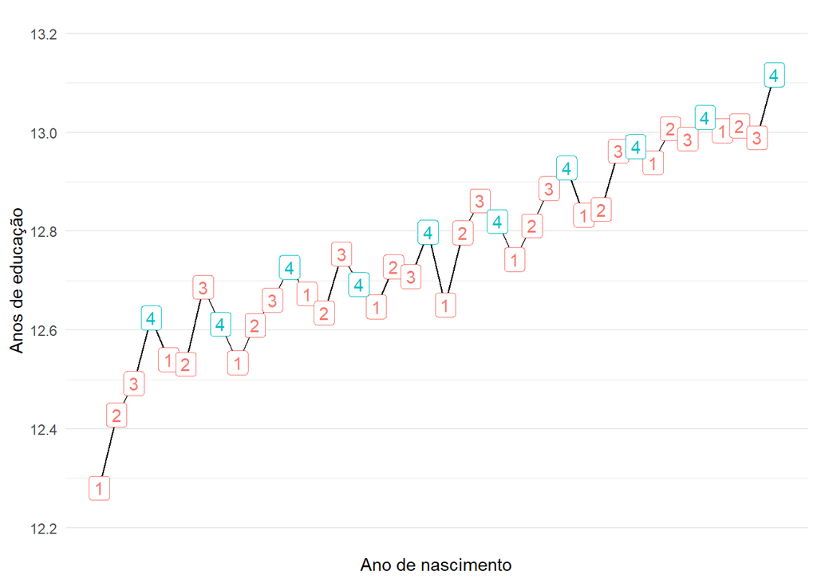

```r
ggplot(ak91_age, aes(x = year_of_birth + (quarter_of_birth - 1) / 4, y = years_of_schooling)) +
  geom_line() +
  geom_label(mapping = aes(label = quarter_of_birth, color = q4)) +
  theme_minimal() +
  theme(legend.position = "none") +
  scale_x_continuous("Ano de nascimento", breaks = 1930:1940) +
  scale_y_continuous("Anos de educação", breaks = seq(12.2, 13.2, by = 0.2),
                     limits = c(12.2, 13.2))
```

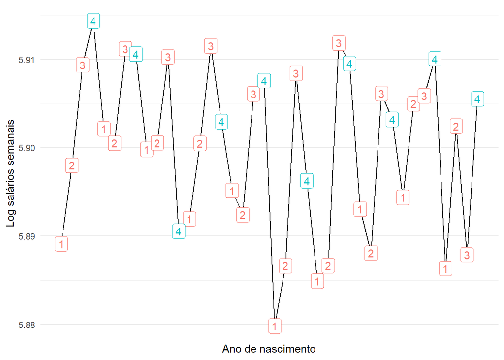

```r
ggplot(ak91_age, aes(x = year_of_birth + (quarter_of_birth - 1) / 4, y = log_wage)) +
  geom_line() +
  geom_label(mapping = aes(label = quarter_of_birth, color = q4)) +
  theme_minimal() +
  scale_x_continuous("Ano de nascimento", breaks = 1930:1940) +
  scale_y_continuous("Log salários semanais") +
  theme(legend.position = "none")
```